# Midterm Project - Evelynn Rhodes BSC4933L

# code :

```r
knitr::opts_chunk$set(echo = TRUE)
```

#### First loading necessary packages

```r
BiocManager::install("edgeR")
library(edgeR)
```

#### First loading necessary ;libraries such as edgeR, dplyr, ggplot2, tidyr, and pheatmp

```r
library(edgeR)
#edge R manual: https://www.bioconductor.org/packages/devel/bioc/vignettes/edgeR/inst/doc/edgeRUsersGuide.pdf
library(dplyr)
```

```r
library(ggplot2)
library(tidyr)
library(pheatmap)
```

#### Loading the dataset with read.csv function, seeing summary of data with head and dimensions and then converting the first column to be named gene_id

```r
CountTable1<-read.csv("MidtermData.csv",header = T)

head(CountTable1)
```

```
##          Column1 X0point1.uM.dist.sample.1 X0point1.uM.dist.sample.2
## 1 AMEX60DD000001                      0.00                      1.63
## 2 AMEX60DD000002                      7.24                      2.74
## 3 AMEX60DD000003                     33.97                     26.17
## 4 AMEX60DD000004                      5.35                      2.19
## 5 AMEX60DD000005                     16.70                      7.27
## 6 AMEX60DD000006                     25.55                     13.90
##   X0point1.uM.dist.sample.3 X1.uM.dist.sample.1 X1.uM.dist.sample.2
## 1                      1.84                1.60                3.66
## 2                      4.06                3.48                2.77
## 3                     45.10               44.21               49.55
## 4                      7.21               10.27                7.16
## 5                     17.88               28.20               13.60
## 6                     22.86               48.23               26.94
##   X1.uM.dist.sample.3 X5.uM.dist.sample.1 X5.uM.dist.sample.2
```

[output cut: 20 more lines]

```r
dim(CountTable1)
```

```
## [1] 99081    16
```

```r
colnames(CountTable1)[1] <- "gene_id"
rownames(CountTable1)<-CountTable1$gene_id
head(CountTable1)
```

```
##                       gene_id X0point1.uM.dist.sample.1
## AMEX60DD000001 AMEX60DD000001                      0.00
## AMEX60DD000002 AMEX60DD000002                      7.24
## AMEX60DD000003 AMEX60DD000003                     33.97
## AMEX60DD000004 AMEX60DD000004                      5.35
## AMEX60DD000005 AMEX60DD000005                     16.70
## AMEX60DD000006 AMEX60DD000006                     25.55
##                X0point1.uM.dist.sample.2 X0point1.uM.dist.sample.3
## AMEX60DD000001                      1.63                      1.84
## AMEX60DD000002                      2.74                      4.06
## AMEX60DD000003                     26.17                     45.10
## AMEX60DD000004                      2.19                      7.21
## AMEX60DD000005                      7.27                     17.88
## AMEX60DD000006                     13.90                     22.86
##                X1.uM.dist.sample.1 X1.uM.dist.sample.2 X1.uM.dist.sample.3
## AMEX60DD000001                1.60                3.66                1.87
## AMEX60DD000002                3.48                2.77                2.86
## AMEX60DD000003               44.21               49.55               42.84
## AMEX60DD000004               10.27                7.16                3.89
## AMEX60DD000005               28.20               13.60               18.34
## AMEX60DD000006               48.23               26.94               12.33
##                X5.uM.dist.sample.1 X5.uM.dist.sample.2 X5.uM.dist.sample.3
## AMEX60DD000001                7.65                0.00               17.50
## AMEX60DD000002                4.56                0.54                0.64
## AMEX60DD000003               47.82               17.08               40.81
## AMEX60DD000004                4.17                2.30                4.14
## AMEX60DD000005               11.60                0.00                9.30
## AMEX60DD000006               37.10                7.60                8.43
##                DMSO.dist.sample.1 DMSO.dist.sample.2 DMSO.dist.sample.3
## AMEX60DD000001               1.88              10.10               2.79
## AMEX60DD000002               2.37               2.03               2.42
## AMEX60DD000003              32.77              32.95              35.73
## AMEX60DD000004               1.71               4.98               1.56
## AMEX60DD000005               7.89               8.87               4.21
## AMEX60DD000006              16.12              24.96              15.39
##                DMSO.prox.sample.1 DMSO.prox.sample.2 DMSO.prox.sample.3
## AMEX60DD000001               2.87               6.46               4.74
## AMEX60DD000002               3.11               1.96               0.62
## AMEX60DD000003              38.98              25.99              29.46
## AMEX60DD000004               3.60               4.62               2.87
## AMEX60DD000005               6.34               9.45               9.23
## AMEX60DD000006              29.28              17.32              10.09
```

#### Grouping the data by aligning conditions to replicates with the groupings. Then create a DGEList object with edgeR. Then looking at the DGE list to see the data to see if gene_id correctly mapped and the counts

```r
groupings<-c("0.1-uM", "0.1-uM", "0.1-uM", "1-uM", "1-uM", "1-uM", "5-uM", "5-uM", "5-uM", "DMSO-dist", "DMSO-dist", "DMSO-dist","DMSO-prox","DMSO-prox", "DMSO-prox")

d1<-DGEList(counts=CountTable1,group=factor(groupings))
```

```
## Setting first column of `counts` as gene annotation.
```

```r
d1$samples #metadata about each sample (library size, group, etc.)
```

```
##                               group lib.size norm.factors
## X0point1.uM.dist.sample.1    0.1-uM  9209432            1
## X0point1.uM.dist.sample.2    0.1-uM  8652567            1
## X0point1.uM.dist.sample.3    0.1-uM 10940100            1
## X1.uM.dist.sample.1            1-uM 13937318            1
## X1.uM.dist.sample.2            1-uM 13061091            1
## X1.uM.dist.sample.3            1-uM 11977855            1
## X5.uM.dist.sample.1            5-uM 13028076            1
## X5.uM.dist.sample.2            5-uM 10609272            1
## X5.uM.dist.sample.3            5-uM 12122446            1
## DMSO.dist.sample.1        DMSO-dist  8926919            1
## DMSO.dist.sample.2        DMSO-dist 10088752            1
## DMSO.dist.sample.3        DMSO-dist 11122731            1
## DMSO.prox.sample.1        DMSO-prox  9877907            1
## DMSO.prox.sample.2        DMSO-prox  8541446            1
## DMSO.prox.sample.3        DMSO-prox  8409618            1
```

```r
head(d1$genes) #gene_ids
```

```
##                       gene_id
## AMEX60DD000001 AMEX60DD000001
## AMEX60DD000002 AMEX60DD000002
## AMEX60DD000003 AMEX60DD000003
## AMEX60DD000004 AMEX60DD000004
## AMEX60DD000005 AMEX60DD000005
## AMEX60DD000006 AMEX60DD000006
```

```r
head(d1$counts) #gene expression counts
```

```
##                X0point1.uM.dist.sample.1 X0point1.uM.dist.sample.2
## AMEX60DD000001                      0.00                      1.63
## AMEX60DD000002                      7.24                      2.74
## AMEX60DD000003                     33.97                     26.17
## AMEX60DD000004                      5.35                      2.19
## AMEX60DD000005                     16.70                      7.27
## AMEX60DD000006                     25.55                     13.90
##                X0point1.uM.dist.sample.3 X1.uM.dist.sample.1
## AMEX60DD000001                      1.84                1.60
## AMEX60DD000002                      4.06                3.48
## AMEX60DD000003                     45.10               44.21
## AMEX60DD000004                      7.21               10.27
## AMEX60DD000005                     17.88               28.20
## AMEX60DD000006                     22.86               48.23
##                X1.uM.dist.sample.2 X1.uM.dist.sample.3 X5.uM.dist.sample.1
## AMEX60DD000001                3.66                1.87                7.65
## AMEX60DD000002                2.77                2.86                4.56
## AMEX60DD000003               49.55               42.84               47.82
## AMEX60DD000004                7.16                3.89                4.17
## AMEX60DD000005               13.60               18.34               11.60
## AMEX60DD000006               26.94               12.33               37.10
##                X5.uM.dist.sample.2 X5.uM.dist.sample.3 DMSO.dist.sample.1
## AMEX60DD000001                0.00               17.50               1.88
## AMEX60DD000002                0.54                0.64               2.37
## AMEX60DD000003               17.08               40.81              32.77
## AMEX60DD000004                2.30                4.14               1.71
## AMEX60DD000005                0.00                9.30               7.89
## AMEX60DD000006                7.60                8.43              16.12
##                DMSO.dist.sample.2 DMSO.dist.sample.3 DMSO.prox.sample.1
## AMEX60DD000001              10.10               2.79               2.87
## AMEX60DD000002               2.03               2.42               3.11
## AMEX60DD000003              32.95              35.73              38.98
## AMEX60DD000004               4.98               1.56               3.60
## AMEX60DD000005               8.87               4.21               6.34
## AMEX60DD000006              24.96              15.39              29.28
##                DMSO.prox.sample.2 DMSO.prox.sample.3
## AMEX60DD000001               6.46               4.74
## AMEX60DD000002               1.96               0.62
## AMEX60DD000003              25.99              29.46
## AMEX60DD000004               4.62               2.87
## AMEX60DD000005               9.45               9.23
## AMEX60DD000006              17.32              10.09
```

#### Calculated norm factors of the table, so the samples have a norm.factor column.Then reduce number of genes to only ones that had a cpm of greater than one in at least four of the samples; genes with meaningful expression are kept.

```r
d1<-calcNormFactors(d1) #adjusts for differences in library sizes across samples, ensuring expression values are comparable

d1$samples
```

```
##                               group lib.size norm.factors
## X0point1.uM.dist.sample.1    0.1-uM  9209432    1.0627366
## X0point1.uM.dist.sample.2    0.1-uM  8652567    1.0213966
## X0point1.uM.dist.sample.3    0.1-uM 10940100    0.9208104
## X1.uM.dist.sample.1            1-uM 13937318    1.1681335
## X1.uM.dist.sample.2            1-uM 13061091    1.0433453
## X1.uM.dist.sample.3            1-uM 11977855    1.0142594
## X5.uM.dist.sample.1            5-uM 13028076    1.1720421
## X5.uM.dist.sample.2            5-uM 10609272    0.7032115
## X5.uM.dist.sample.3            5-uM 12122446    0.8270624
## DMSO.dist.sample.1        DMSO-dist  8926919    0.9713236
## DMSO.dist.sample.2        DMSO-dist 10088752    1.1063350
## DMSO.dist.sample.3        DMSO-dist 11122731    1.0351593
## DMSO.prox.sample.1        DMSO-prox  9877907    1.0889528
## DMSO.prox.sample.2        DMSO-prox  8541446    0.9309943
## DMSO.prox.sample.3        DMSO-prox  8409618    1.0528315
```

```r
dim(d1)
```

```
## [1] 99081    15
```

```r
keep_filter<-rowSums(cpm(d1)>1)>=4

d1<-d1[keep_filter,]
dim(d1)
```

```
## [1] 39781    15
```

#### EdgeR’s negative binomial distribution to show how much “noise” is in the genes expressed (allows edgeR to show truly differentialty expressed genes instead of genes that were expressed by chance). MDS_plot shows a first view into biological similarity/distance between each sample based on expression. Look into areas such as clustering of replicates across a condition to see if they had a similar expression.

```r
d1<-estimateDisp(d1)
```

```
## Using classic mode.
```

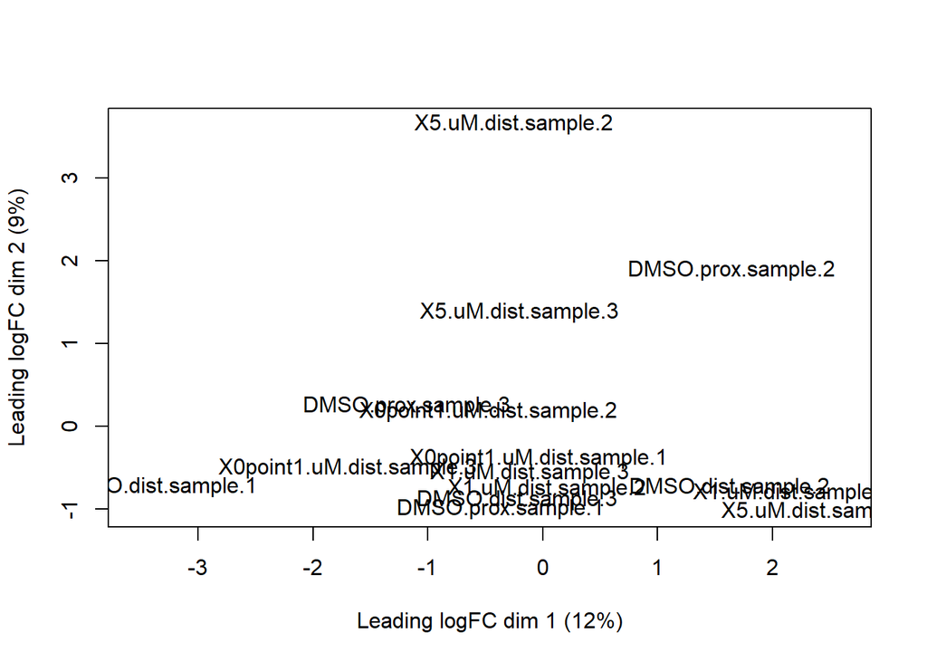

```r
MDS_plot<-plotMDS(d1)
```